# MÃ©dailles Jeux Olympiques d’hiver de 1924 Ã 2010

### 2.1.1 Le moins ?

Nous allons ensuite extraire les 10 pays qui ont gagné le moins de médailles sur ces 86 années.

```r
donnees%>%group_by(code)%>%summarise(N=n())%>%arrange(N)%>%slice(1:10)
```

```
## # A tibble: 10 × 2
##     code     N
##    <chr> <int>
## 1    DEN     1
## 2    NZL     1
## 3    ROU     1
## 4    UZB     1
## 5    ESP     2
## 6    LUX     2
## 7    PRK     2
## 8    LAT     3
## 9    SVK     4
## 10   YUG     4
```

On peut voir que tous ces pays ont gagné moins de 5 médailles au JO d’hiver.

Maintenant que nous avons vu les pays qui gagnent le plus et le moins de médailles couleurs confondues, nous allons regarder pour chaque couleur de médaille afin de voir si ce sont toujours les mêmes pays et dans le même ordre.

## 2.2 Selon la couleur de la médaille

### 2.2.1 Or

Nous allons faire comme précédemment mais en ne sélectionnant que les médailles d’or.

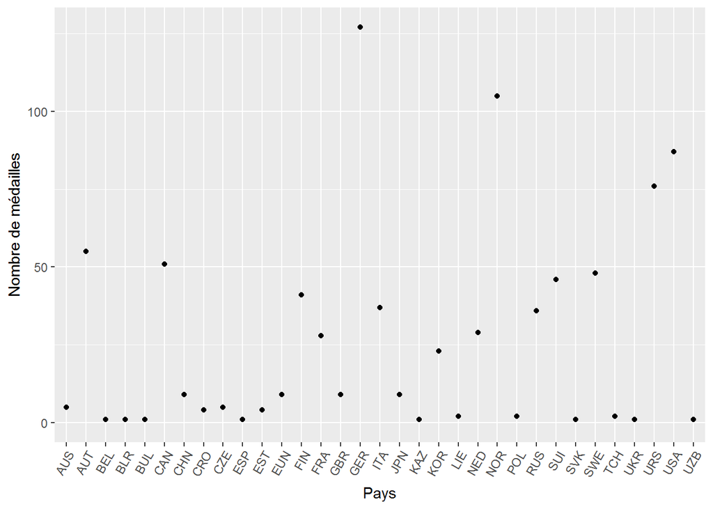

```r
MedailleOr<-donnees%>%group_by(code)%>%filter(medal=='gold')%>%summarise(N=n())%>%arrange(-N)%>%slice(1:10)
donnees%>%group_by(code)%>%filter(medal=='gold')%>%summarise(N=n())%>%ggplot(aes(x=code, y=N))+geom_point(width=0.3)+xlab("Pays")+ylim(0,NA)+ylab("Nombre de médailles")+ theme(axis.text.x = element_text(angle = 60, vjust = 1, hjust=1))
```

Comme il n’est pas très facile de confronter le plot des médailles toutes couleurs confondues et des médailles d’or, et afin de répondre à notre question, nous allons confronter les liste des 10 pays qui ont gagné le plus dans les deux cas.

```r
tout<-MedailleGeneral%>%mutate(ordre=1:10)%>%select(code,ordre)%>%arrange(code)
```

```r
or<-MedailleOr%>%mutate(ordre=1:10)%>%select(code,ordre)%>%arrange(code)
```

```r
tout$code
```

```
##  [1] "AUT" "CAN" "FIN" "GER" "ITA" "NOR" "SUI" "SWE" "URS" "USA"
```

```r
tout$ordre
```

```
##  [1]  4  7  6  1 10  2  9  8  5  3
```

```r
or$ordre
```

```
##  [1]  5  6  9  1 10  2  8  7  4  3
```

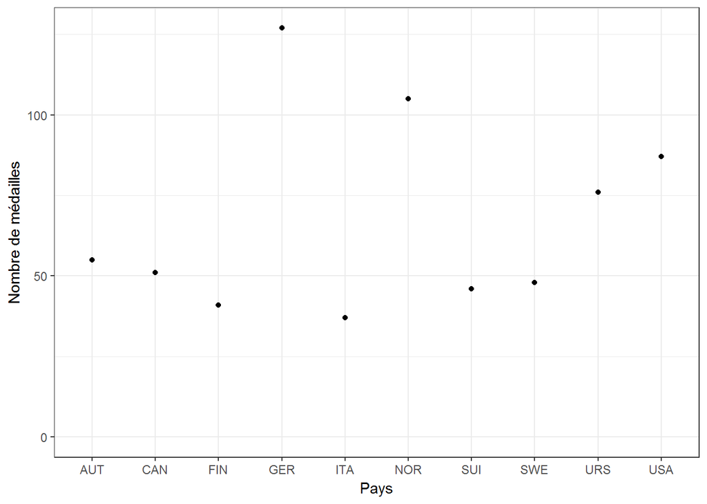

```r
donnees%>%group_by(code)%>%filter(medal=='gold')%>%summarise(N=n())%>%arrange(-N)%>%slice(1:10)%>%ggplot(aes(x=code, y=N))+geom_point(width=0.3)+xlab("Pays")+ylim(0,NA)+ylab("Nombre de médailles")+theme_bw()
```

L’allure de ce graphique est similaire au précédent concernant les médailles en général, les écart entre les différents pays sont respectés, par exemple l’Allemagne et la Norvège se distinguent toujours autant.

### 2.2.2 Argent

Nous allons rapidement regarder si c’est la même chosse pour les médailles d’argent

```r
MedailleArgent<-donnees%>%group_by(code)%>%filter(medal=='silver')%>%summarise(N=n())%>%arrange(-N)%>%slice(1:10)%>%arrange(code)
MedailleArgent
```

```
## # A tibble: 10 × 2
##     code     N
##    <chr> <int>
## 1    AUT    70
## 2    CAN    48
## 3    FIN    59
## 4    GER   129
## 5    ITA    32
## 6    NOR   107
## 7    SUI    36
## 8    SWE    34
## 9    URS    58
## 10   USA    90
```

Ce sont toujours les 10 mêmes pays.

```r
argent<-MedailleOr%>%mutate(ordre=1:10)%>%select(code,ordre)%>%arrange(code)
tout$code
```

```
##  [1] "AUT" "CAN" "FIN" "GER" "ITA" "NOR" "SUI" "SWE" "URS" "USA"
```

```r
tout$ordre
```

```
##  [1]  4  7  6  1 10  2  9  8  5  3
```

```r
or$ordre
```

```
##  [1]  5  6  9  1 10  2  8  7  4  3
```

```r
argent$ordre
```

```
##  [1]  5  6  9  1 10  2  8  7  4  3
```

Encore une fois l’ordre du podium est conservé et comme pour les médailles d’or, très peu de mouvement de rangs.

### 2.2.3 Bronze

Et enfin pour les medailles de bronze :

```r
MedailleBronze<-donnees%>%group_by(code)%>%filter(medal=='bronze')%>%summarise(N=n())%>%arrange(-N)%>%slice(1:10)
MedailleBronze%>%mutate(ordre=1:10)
```

```
## # A tibble: 10 × 3
##     code     N ordre
##    <chr> <int> <int>
## 1    GER   103     1
## 2    NOR    90     2
## 3    AUT    76     3
## 4    USA    76     4
## 5    URS    58     5
## 6    FIN    55     6
## 7    CAN    47     7
## 8    SWE    47     8
## 9    SUI    46     9
## 10   FRA    42    10
```

Cette fois nous ne pouvons pas faire la même méthode car un pays a été remplace : la France a plus gagné de médaille que l’Italie ce qui l’a fait sortir du top 10. L’Autriche a également fait sa place au détriment des Etats Unis

Ainsi, on peut dire que le top 10 des nations qui gagnent le plus de médailles en général, d’or, d’argent ou de bronze reste constant mis à part l’Italie et la France qui échangent la place numéro 10. Nous allons maintenant regarder pour chaque JO, quels ont été les pays qui ont le plus gagné.

# 3 Analyse par Jeux Olympiques

Dans cette partie, nous avons choisi de ne conserver que les trois nations qui ont gagné le plus de médailles par année de JO.

```r
yearCode<-donnees%>%group_by(year,code)%>%summarise(N=n())%>%arrange(-N)%>%slice(1:3)
yearCode
```

```
## Source: local data frame [63 x 3]
## Groups: year [21]
##
##     year  code     N
##    <int> <chr> <int>
## 1   1924   NOR    16
## 2   1924   FIN    11
## 3   1924   GBR     4
## 4   1928   NOR    14
## 5   1928   USA     6
## 6   1928   SWE     5
## 7   1932   USA    12
## 8   1932   NOR    10
## 9   1932   CAN     7
## 10  1936   NOR    15
## # ... with 53 more rows
```

# 4 Analyse par sport

```r
donnees%>%group_by(sport,code)%>%summarise(N=n())%>%arrange(-N)%>%slice(1:3)
```

```
## Source: local data frame [45 x 3]
## Groups: sport [15]
##
##           sport  code     N
##           <chr> <chr> <int>
## 1  alpineskiing   AUT   105
## 2  alpineskiing   SUI    55
## 3  alpineskiing   FRA    43
## 4      biathlon   GER    59
## 5      biathlon   NOR    29
## 6      biathlon   RUS    20
## 7     bobsleigh   GER    40
## 8     bobsleigh   SUI    30
## 9     bobsleigh   USA    20
## 10 crosscountry   NOR    96
## # ... with 35 more rows
```

# 5 Evolution dans le remps

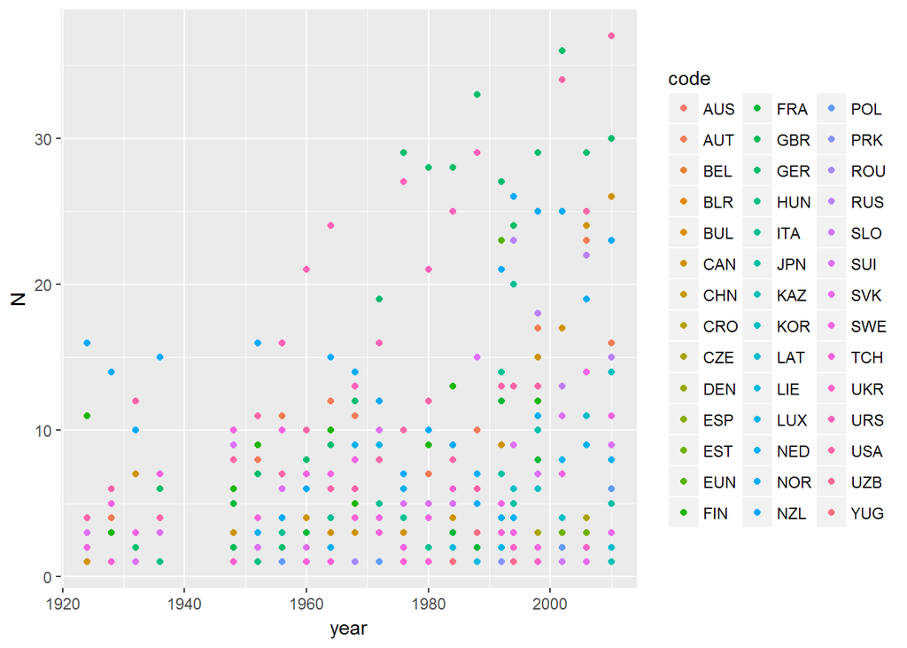

```r
donnees%>%group_by(year,code)%>%summarise(N=n())%>%ggplot(aes(x=year, y=N, color=code))+geom_point()
```

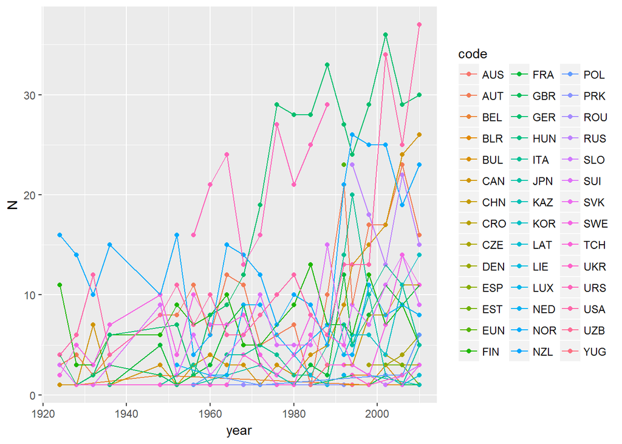

```r
donnees%>%group_by(year,code)%>%summarise(N=n())%>%ggplot(aes(x=year, y=N, color=code))+geom_point()+geom_line()
```

ATTENTION

[output not shown]

[output cut: 16 more lines]

[output not shown]

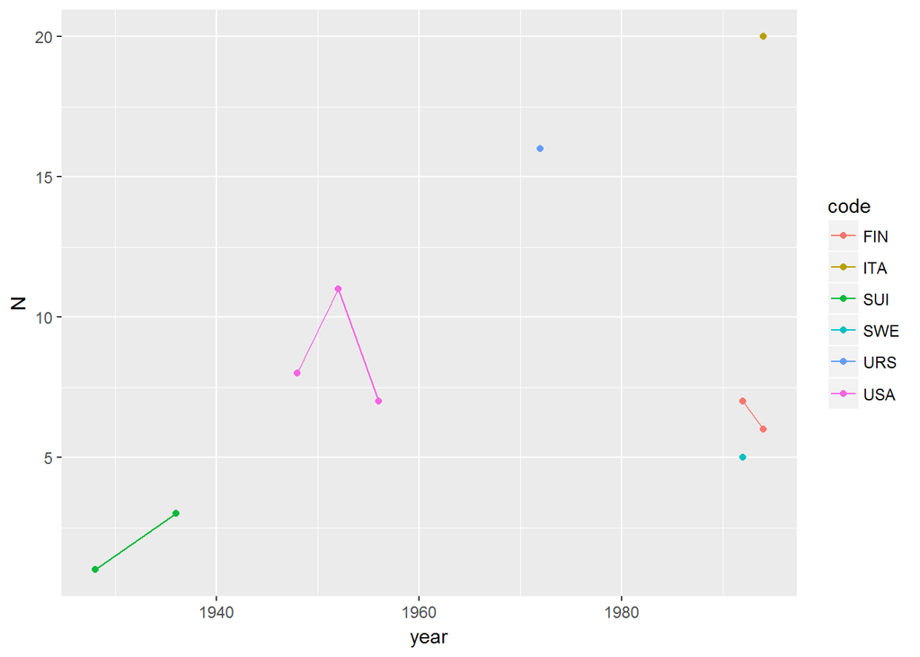

```r
donnees%>%group_by(year,code)%>%summarise(N=n())%>%filter(code==c('GER','NOR','USA','AUT','URS','FIN','CAN','SWE','SUI','ITA'))%>%ggplot(aes(x=year, y=N, color=code))+geom_point()+geom_line()
```

```r
#(donnees$year - min( donnees$year))/4

#donnees %>% mutate(year2=(year-min(year))/4)

#donnees%>%group_by(year,code)%>%summarise(N=n())%>%mutate(year2=(year-min(year))/4)
```

[figure not shown]

```r
donnees%>%group_by(year,code)%>%summarise(N=n())%>%mutate(year2=(year-min(year))/4)%>%ggplot(aes(x=year2, y=N, color=code))+geom_point()+geom_line()
```

# 6 Position de la France

```r
donnees%>%group_by(year,sport,code)%>%summarise(N=n())%>%arrange(-N)%>%slice(1)%>%filter(code=='FRA')
```

```
## Source: local data frame [4 x 4]
## Groups: year, sport [4]
##
##    year           sport  code     N
##   <int>           <chr> <chr> <int>
## 1  1924         curling   FRA     1
## 2  1968    alpineskiing   FRA     8
## 3  1992 freestyleskiing   FRA     5
## 4  2010        biathlon   FRA     6
```

```r
donnees%>%group_by(year,sport,code)%>%summarise(N=n())%>%arrange(-N)%>%slice(1:3)%>%filter(code=='FRA')
```

```
## Source: local data frame [22 x 4]
## Groups: year, sport [22]
##
##     year         sport  code     N
##    <int>         <chr> <chr> <int>
## 1   1924      biathlon   FRA     1
## 2   1924       curling   FRA     1
## 3   1924 figureskating   FRA     1
## 4   1928 figureskating   FRA     1
## 5   1936  alpineskiing   FRA     1
## 6   1948  alpineskiing   FRA     5
## 7   1952 figureskating   FRA     1
## 8   1960  alpineskiing   FRA     3
## 9   1964  alpineskiing   FRA     6
## 10  1968  alpineskiing   FRA     8
## # ... with 12 more rows
```